# Practical Machine Learning Assignment

Vishal Gupta

11/2/2017

## BACKGROUND

Using devices such as Jawbone Up, Nike FuelBand, and Fitbit it is now possible to collect a large amount of data about personal activity relatively inexpensively. These type of devices are part of the quantified self movement – a group of enthusiasts who take measurements about themselves regularly to improve their health, to find patterns in their behavior, or because they are tech geeks. One thing that people regularly do is quantify how much of a particular activity they do, but they rarely quantify how well they do it. In this project, your goal will be to use data from accelerometers on the belt, forearm, arm, and dumbell of 6 participants. They were asked to perform barbell lifts correctly and incorrectly in 5 different ways.

## GOAL

Six young health participants were asked to perform one set of 10 repetitions of the Unilateral Dumbbell Biceps Curl in five different fashions: 1. exactly according to the specification (Class A) 2. throwing the elbows to the front (Class B) 3. lifting the dumbbell only halfway (Class C) 4. lowering the dumbbell only halfway (Class D) 5. throwing the hips to the front (Class E).

The goal of the project is to predict the manner in which they did the exercise. This is the “classe” variable in the training set.

## LOADING DATA AND LIBRARIES

Loading the dataset containing training and test dataset

```r
# Loading packages
library(caret)
library(randomForest)
```

```r
library(rpart.plot)
# loading training and resting datasets
trainUrl <- "http://d396qusza40orc.cloudfront.net/predmachlearn/pml-training.csv"
testUrl <- "http://d396qusza40orc.cloudfront.net/predmachlearn/pml-testing.csv"

training <- read.csv(url(trainUrl), na.strings=c("NA","#DIV/0!","NULL",""))
testing <- read.csv(url(testUrl), na.strings=c("NA","#DIV/0!","NULL",""))
```

## CLEANING DATA

Dataset can contain a lot of NAs, so first the number of NA values in each column of training is identified and then those column which have more than 50% of entires as NA have been removed. By doing it all the NA values have been removed from the dataset. Those column are also removed from the test dataset.

```r
# Checking and removing columns where more than 50% of the data is NA
na_count= sapply(training,function(x) sum(is.na(x)))
training = training[,na_count < 0.5*nrow(training)]

# Removing the same column from the test dataset
testing = testing[,na_count < 0.5*nrow(training)]

# Removing column "X" and  as it contains row index only
training = subset(training,select = -X)
testing = subset(testing,select = -X)
```

The training set is divided into train and cross-validation dataset in 70:30 ratio

```r
# Creating train and cross-validation set in training dataset
set.seed(123)
samp = createDataPartition(y=training$classe,p=0.7, list=FALSE)
inTrain = training[samp,]
inTest = training[-samp,]
```

## MODELLING

Different model that will be used to train data and then predict on cross validation set are- 1. Decision trees 2. Bootstrap Aggregating (Bagging) 3. Random Forest 4. Boosting

The best model out of these will be used for predicting on final test dataset containing 20 observations.

Setting cross-validation for training the model

## ESTIMATING OUT OF SAMPLE ERROR

Cross validation can be used to calculate out of sample error for a model. Cross-validation is kind of the same idea as creating single training and testing sets; however, because a single training and testing set would yield unstable estimates due to their limited number of observations, one can create several testing and training sets using different parts of the data and average their estimates of model fit.

We have used k-fold cross validation choosing k=10 as choosing larger k would take longer time to run the models.

```r
# Setting crossvalidation for bagging, boosting and random forest
trainCV = trainControl(method = "cv",number = 10)
```

# Decision Tree

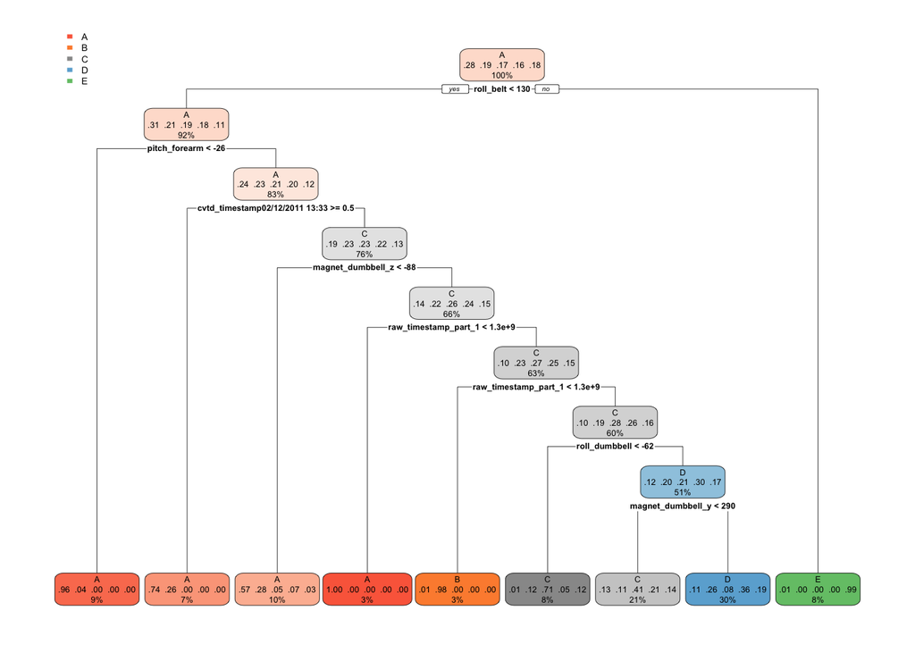

```r
## Decision Trees
# Creating decision trees in inTrain
set.seed(123)
model_trees = train(classe ~ .,method="rpart",data=inTrain,trControl = trainCV)
rpart.plot(model_trees$finalModel)
```

```r
# predicting with decision trees
pred_trees = predict(model_trees,newdata = inTest)
cm1 = confusionMatrix(pred_trees,inTest$classe)
cm1
```

```
## Confusion Matrix and Statistics
##
##           Reference
## Prediction    A    B    C    D    E
##          A 1299  318   27   49   12
##          B    4  166    0    0    0
##          C  160  182  862  319  228
##          D  204  473  137  596  361
##          E    7    0    0    0  481
##
## Overall Statistics
##
##                Accuracy : 0.5784
##                  95% CI : (0.5657, 0.5911)
##     No Information Rate : 0.2845
##     P-Value [Acc > NIR] : < 2.2e-16
##
##                   Kappa : 0.4701
##  Mcnemar's Test P-Value : NA
##
## Statistics by Class:
##
##                      Class: A Class: B Class: C Class: D Class: E
## Sensitivity            0.7760  0.14574   0.8402   0.6183  0.44455
## Specificity            0.9036  0.99916   0.8170   0.7612  0.99854
## Pos Pred Value         0.7619  0.97647   0.4923   0.3365  0.98566
## Neg Pred Value         0.9103  0.82975   0.9603   0.9105  0.88864
## Prevalence             0.2845  0.19354   0.1743   0.1638  0.18386
## Detection Rate         0.2207  0.02821   0.1465   0.1013  0.08173
## Detection Prevalence   0.2897  0.02889   0.2975   0.3009  0.08292
## Balanced Accuracy      0.8398  0.57245   0.8286   0.6897  0.72154
```

# Bagging

```r
## Bagging
# Creating bagging in inTrain
set.seed(123)
model_bagging = train(classe ~ .,method = "treebag",data = inTrain,trControl = trainCV)
# predicting with decision trees
pred_bagging = predict(model_bagging,newdata = inTest)
cm2 = confusionMatrix(pred_bagging,inTest$classe)
cm2
```

```
## Confusion Matrix and Statistics
##
##           Reference
## Prediction    A    B    C    D    E
##          A 1674    2    0    0    0
##          B    0 1136    3    0    0
##          C    0    0 1023    1    0
##          D    0    1    0  962    0
##          E    0    0    0    1 1082
##
## Overall Statistics
##
##                Accuracy : 0.9986
##                  95% CI : (0.9973, 0.9994)
##     No Information Rate : 0.2845
##     P-Value [Acc > NIR] : < 2.2e-16
##
##                   Kappa : 0.9983
##  Mcnemar's Test P-Value : NA
##
## Statistics by Class:
##
##                      Class: A Class: B Class: C Class: D Class: E
## Sensitivity            1.0000   0.9974   0.9971   0.9979   1.0000
## Specificity            0.9995   0.9994   0.9998   0.9998   0.9998
## Pos Pred Value         0.9988   0.9974   0.9990   0.9990   0.9991
## Neg Pred Value         1.0000   0.9994   0.9994   0.9996   1.0000
## Prevalence             0.2845   0.1935   0.1743   0.1638   0.1839
## Detection Rate         0.2845   0.1930   0.1738   0.1635   0.1839
## Detection Prevalence   0.2848   0.1935   0.1740   0.1636   0.1840
## Balanced Accuracy      0.9998   0.9984   0.9984   0.9989   0.9999
```

# Random Forest

```r
## Random forest
# Creating random forest in inTrain
set.seed(123)
model_rf = train(classe ~ .,method = "rf",data = inTrain,trControl = trainCV)
# predicting with decision trees
pred_rf = predict(model_rf,newdata = inTest)
cm3 = confusionMatrix(pred_rf,inTest$classe)
cm3
```

```
## Confusion Matrix and Statistics
##
##           Reference
## Prediction    A    B    C    D    E
##          A 1674    0    0    0    0
##          B    0 1139    3    0    0
##          C    0    0 1023    1    0
##          D    0    0    0  962    0
##          E    0    0    0    1 1082
##
## Overall Statistics
##
##                Accuracy : 0.9992
##                  95% CI : (0.998, 0.9997)
##     No Information Rate : 0.2845
##     P-Value [Acc > NIR] : < 2.2e-16
##
##                   Kappa : 0.9989
##  Mcnemar's Test P-Value : NA
##
## Statistics by Class:
##
##                      Class: A Class: B Class: C Class: D Class: E
## Sensitivity            1.0000   1.0000   0.9971   0.9979   1.0000
## Specificity            1.0000   0.9994   0.9998   1.0000   0.9998
## Pos Pred Value         1.0000   0.9974   0.9990   1.0000   0.9991
## Neg Pred Value         1.0000   1.0000   0.9994   0.9996   1.0000
## Prevalence             0.2845   0.1935   0.1743   0.1638   0.1839
## Detection Rate         0.2845   0.1935   0.1738   0.1635   0.1839
## Detection Prevalence   0.2845   0.1941   0.1740   0.1635   0.1840
## Balanced Accuracy      1.0000   0.9997   0.9984   0.9990   0.9999
```

# Boosting

```r
## Boosting
# Creating boosting in inTrain
set.seed(123)
model_gbm = train(classe ~ .,method = "gbm",data = inTrain,trControl = trainCV)
# predicting with decision trees
pred_gbm = predict(model_gbm,newdata = inTest)
cm4 = confusionMatrix(pred_gbm,inTest$classe)
cm4
```

```
## Confusion Matrix and Statistics
##
##           Reference
## Prediction    A    B    C    D    E
##          A 1673    0    0    0    0
##          B    1 1135    1    0    0
##          C    0    2 1019    1    0
##          D    0    2    6  961    2
##          E    0    0    0    2 1080
##
## Overall Statistics
##
##                Accuracy : 0.9971
##                  95% CI : (0.9954, 0.9983)
##     No Information Rate : 0.2845
##     P-Value [Acc > NIR] : < 2.2e-16
##
##                   Kappa : 0.9963
##  Mcnemar's Test P-Value : NA
##
## Statistics by Class:
##
##                      Class: A Class: B Class: C Class: D Class: E
## Sensitivity            0.9994   0.9965   0.9932   0.9969   0.9982
## Specificity            1.0000   0.9996   0.9994   0.9980   0.9996
## Pos Pred Value         1.0000   0.9982   0.9971   0.9897   0.9982
## Neg Pred Value         0.9998   0.9992   0.9986   0.9994   0.9996
## Prevalence             0.2845   0.1935   0.1743   0.1638   0.1839
## Detection Rate         0.2843   0.1929   0.1732   0.1633   0.1835
## Detection Prevalence   0.2843   0.1932   0.1737   0.1650   0.1839
## Balanced Accuracy      0.9997   0.9980   0.9963   0.9974   0.9989
```

# Choosing the best model

Comparing the accuracy of all the four model on cross validated dataset, the accuracy of the Decision tree model is very less compared to other models. While the rest three models are very close, accuracy > 99%. Using sensitivity and specificity for each classe as the final measure to select between the three models, Random forest comes out as the best model.

```r
accuracy = data.frame(DecisionTree = cm1$overall[1],Bagging = cm2$overall[1],
                      RandomForest = cm3$overall[1],Boosting = cm4$overall[1])
accuracy
```

```
##          DecisionTree   Bagging RandomForest  Boosting
## Accuracy    0.5784197 0.9986406    0.9991504 0.9971113
```

[figure not shown]

```r
par(mfrow=c(2,2))
plot(cm1$byClass, main="Decision Tree", xlim=c(0, 1), ylim=c(0, 1))
text(cm1$byClass[,1], cm1$byClass[,2], labels=LETTERS[1:5], cex= 0.8)
plot(cm2$byClass, main="Random Forest", xlim=c(0.9, 1),ylim=c(0.9, 1))
text(cm2$byClass[,1], cm2$byClass[,2], labels=LETTERS[1:5], cex= 0.8)
plot(cm3$byClass, main="Boosting", xlim=c(0.9, 1),ylim=c(0.9, 1))
text(cm3$byClass[,1], cm3$byClass[,2], labels=LETTERS[1:5], cex= 0.8)
plot(cm4$byClass, main="Bagging", xlim=c(0.9, 1), ylim=c(0.9, 1))
text(cm4$byClass[,1], cm4$byClass[,2], labels=LETTERS[1:5], cex= 0.8)
```

## RESULTS

Using Random forest, predicting on the final test dataset

```r
# Random forest is choosen
# predicting for final test set
pred_final = predict(model_rf,newdata = testing)
pred_final
```

```
##  [1] B A B A A E D B A A B C B A E E A B B B
## Levels: A B C D E
```